# PS5: INFO 201

# 4 GDP per capita (50pt)

Let’s look at GDP per capita (*GDP_PC*)

1. (8pt) Make a scatterplot of GDP per capita versus life expectancy by country, using data for 1960. Make the point size dependent on the country size, and color those according to the continent. Feel free to adjust the plot in other ways to make it better.  
   Comment what do you see there.

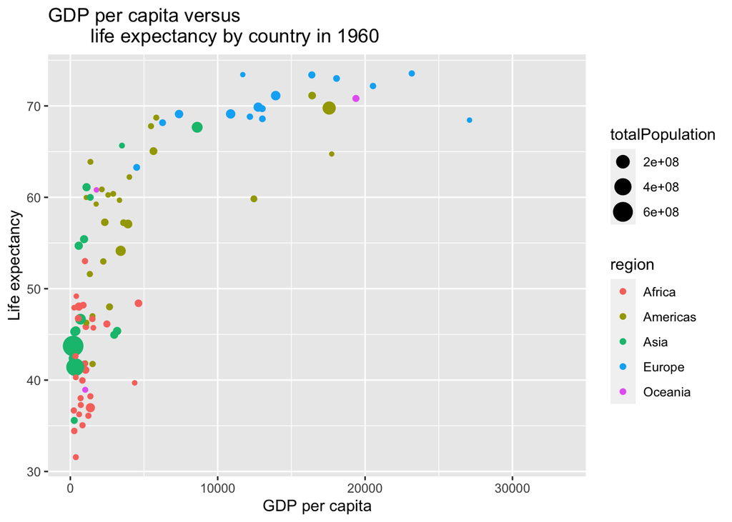

```r
filter_gapminder <- gapminder %>%
  filter(!is.na(GDP_PC))
ggplot(data = subset(filter_gapminder, time == 1960),
       aes(x = GDP_PC, y = lifeExpectancy)) +
  geom_point(aes(size = totalPopulation, color = region)) +
  labs(x = "GDP per capita", y = "Life expectancy", title = "GDP per capita versus
        life expectancy by country in 1960")
```

```r
# This scatterplot gives us data for 1960.
# We can see that the blue dots tend to be smaller and closer to the top of the scatterplot.
# This tells us that Europe tends to have countries with smaller, yet high GDP per capita countries.
# On the contrary, Africa (red dots) tends to have countries with small but low GDP per captia countries.
# The bigger dots (such as Asian countries) tend to also to be on the lower GDP per capita side.
# Overall, we can observe that as GDP per capita increases, Life expectancy increases logarithmically.
```

2. (4pt) Make a similar plot, but this time use 2019 data only.

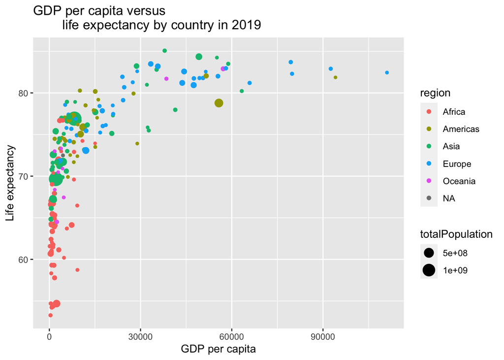

```r
filter_gapminder <- gapminder %>%
  filter(!is.na(GDP_PC))
ggplot(data = subset(filter_gapminder, time == 2019),
       aes(x = GDP_PC, y = lifeExpectancy)) +
  geom_point(aes(size = totalPopulation, color = region)) +
  labs(x = "GDP per capita", y = "Life expectancy", title = "GDP per capita versus
        life expectancy by country in 2019")
```

```r
# We see a similar pattern in this scatterplot, which gives us data for 2019,
# has a similar trend to the 1960 scatterplot. In both, we can observe that as
# GDP per capita increases, Life expectancy increases logarithmically.
```

3. (6pt) Compare these two plots and comment what do you see. How has world developed through the last 60 years?

```r
# Like I mentioned before, both scatterplots indicate the same trend: as
# GDP per capita increases, Life expectancy increases logarithmically.
# One main difference between the two plots is in the 1960 plot, the minimum life
# expectancy age was 32 years old by an African country and the maximum
# age was 74 by a European country. However, for 2019, the minimumm
# life expectancy age was 53 by an African country, but the maximum age was 85
# by an Asian country. Additionally, the scale for the total population is larger
# indicating that the overall population numbers increased over the years. Finally,
# I noticed that in 1960, the Asian countries tended to lay towards the left of the graph
# indicating that they had low GDP per capita, but average life expectancy. In
# 2019, however, the asian countries, on average, tended to have a higher life
# expectancy. The overall location of all the continents remain similar as you
# look between both graphs.
```

4. (6pt) Compute the average life expectancy for each continent in 1960 and 2019. Do the results fit with what do you see on the figures?  
   Note: here as *average*I mean just average over countries, ignore the fact that countries are of different size.

```r
avg_le_1960 <- gapminder %>%
  filter(!is.na(lifeExpectancy)) %>%
  filter(time == 1960) %>%
  group_by(region) %>%
  summarise(avg_le_1960 = mean(lifeExpectancy))
avg_le_1960
```

```
## # A tibble: 6 × 2
##   region   avg_le_1960
##   <chr>          <dbl>
## 1 Africa          41.5
## 2 Americas        58.6
## 3 Asia            51.6
## 4 Europe          68.3
## 5 Oceania         56.4
## 6 <NA>            70.7
```

```r
avg_le_2019 <- gapminder %>%
  filter(!is.na(lifeExpectancy)) %>%
  filter(time == 2019) %>%
  group_by(region) %>%
  summarise(avg_le_2019 = mean(lifeExpectancy))
avg_le_2019
```

```
## # A tibble: 6 × 2
##   region   avg_le_2019
##   <chr>          <dbl>
## 1 Africa          64.1
## 2 Americas        75.8
## 3 Asia            74.6
## 4 Europe          79.4
## 5 Oceania         73.5
## 6 <NA>            77.8
```

```r
# Yes, these results fit with I noticed on the figures. Looking at any specific
# continent, the life expectancy increased from 1960 to 2019.
```

5. (8pt) Compute the average LE growth from 1960-2019 across the continents. Show the results in the order of growth. Explain what do you see.  
   Hint: these data (data in long form) is not the simplest to compute growth. But you may want to check out the lag() function. And do not forget to group data by continent when using lag(), otherwise your results will be messed up! See [**https://faculty.washington.edu/otoomet/info201-book/dplyr.html#dplyr-helpers-compute**](https://faculty.washington.edu/otoomet/info201-book/dplyr.html#dplyr-helpers-compute).

```r
gapminder %>%
  filter(!is.na(region), !is.na(time), !is.na(lifeExpectancy)) %>%
  filter(time %in% c("1960", "2019")) %>%
  group_by(region,time) %>%
  summarize(avg_LE_2019 = mean(lifeExpectancy)) %>%
  mutate(avg_LE_1960 = lag(avg_LE_2019, default = NA), avg_LE_growth = avg_LE_2019 - avg_LE_1960) %>%
  arrange(desc(avg_LE_growth)) %>%
  head(5)
```

```
## # A tibble: 5 × 5
## # Groups:   region [5]
##   region    time avg_LE_2019 avg_LE_1960 avg_LE_growth
##   <chr>    <dbl>       <dbl>       <dbl>         <dbl>
## 1 Asia      2019        74.6        51.6          23.0
## 2 Africa    2019        64.1        41.5          22.6
## 3 Americas  2019        75.8        58.6          17.2
## 4 Oceania   2019        73.5        56.4          17.1
## 5 Europe    2019        79.4        68.3          11.1
```

```r
# We see that Asia had the highest average life expectancy growth from 1960 to 2019.
# Asia had a growth of 22.97 years. Africa had the second highest LE growth of 22.64 years.
# Americas, with 17.19, years was third, followed by Oceana (17.13 years). Europe (11.07)
# years had the lowest average life expectancy growth from 1960 to 2019.
```

6. (6pt) Show the histogram of GDP per capita for years of 1960 and 2019. Try to put both histograms on the same graph, see how well you can do it!

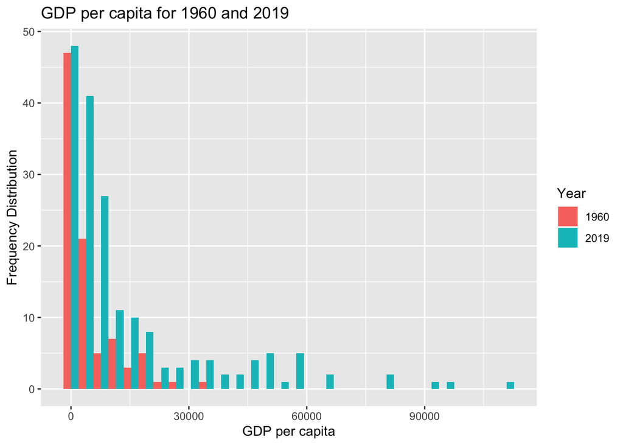

```r
gapminder %>%
  filter(time == 1960 | time == 2019, !is.na(GDP_PC)) %>%
  ggplot(aes(x = GDP_PC, fill = as.factor(time))) +
  geom_histogram(alpha = 1, position = "dodge") +
  labs(x = "GDP per capita", y = "Frequency Distribution",
       title = "GDP per capita for 1960 and 2019", fill = "Year")
```

```r
# In the histogram, we see that the frequency of GDP per capita is higher
# in 2019 than in 1960. Specifically, there are no 1960 values that above
# about 35,000; however, there are plenty such values for 2019. This just shows
# how the economy has improved over the years and GDP tends to increase as
# time goes on.
```

7. (6pt) What was the ranking of US in terms of life expectancy in 1960 and in 2019? (When counting from top.)  
   Hint: check out the function rank()!  
   Hint2: 17 for 1960.

```r
gapminder %>%
  filter(time == 1960, !is.na(lifeExpectancy)) %>%
  filter(name != "") %>%
  mutate(ranking_1960 = rank(desc(lifeExpectancy))) %>%
  filter(name == "United States of America") %>%
  filter(!is.na(ranking_1960)) %>%
  pull(ranking_1960)
```

```
## [1] 17
```

```r
gapminder %>%
  filter(time == 2019, !is.na(lifeExpectancy)) %>%
  filter(name != "") %>%
  mutate(ranking_2019 = rank(desc(lifeExpectancy))) %>%
  filter(name == "United States of America") %>%
  filter(!is.na(ranking_2019)) %>%
  pull(ranking_2019)
```

```
## [1] 46
```

```r
# The life expectancy ranking for the US in 1960 was 17, while the ranking
# in 2019 was 46.
```

8. (6pt) If you did this correctly, then you noticed that US ranking has been falling quite a bit. But we also have more countries in 2019–what about the relative rank divided by the corresponding number of countries that have LE data in the corresponding year?  
   Hint: 0.0904 for 1960.

```r
countries_1960 <- gapminder %>%
  filter(time == 1960, !is.na(lifeExpectancy)) %>%
  filter(name != "") %>%
  summarise(num_countries_1960 = n())
countries_2019 <- gapminder %>%
  filter(time == 2019, !is.na(lifeExpectancy)) %>%
  filter(name != "") %>%
  summarise(num_countries_2019 = n())
relative_rank_1960 <- gapminder %>%
  filter(time == 1960) %>%
  filter(name != "") %>%
  mutate (rank_1960 = rank(desc(lifeExpectancy))) %>%
  filter(name == "United States of America") %>%
  pull(rank_1960)/countries_1960$num_countries_1960
relative_rank_2019 <- gapminder %>%
  filter(time == 2019) %>%
  filter(name != "") %>%
  mutate (rank_2019 = rank(desc(lifeExpectancy))) %>%
  filter(name == "United States of America") %>%
  pull(rank_2019)/countries_2019$num_countries_2019
relative_rank_1960
```

```
## [1] 0.09042553
```

```r
relative_rank_2019
```

```
## [1] 0.2346939
```

```r
# The relative rank for the United States in 1960 was 0.09042553.
# The relative rank for the United States in 2019 was 0.2346939.
```

Finally tell us how many hours did you spend on this PS.

```r
## I spent 7 hours on this problem set.
```